# Homework

21016

2021-12-17

## A-21016-2021-09-16

## Question

Use knitr to produce at least 3 examples (texts, figures, tables).

## Answer

text:  
datasets包中women数据集记录了15个美国女性的体重和身高数据，尝试对其建立回归模型.

```r
library(MASS)
attach(women)
lm_fit<-lm(weight~height)
```

figures:  
画出height和weight的散点图及回归直线.

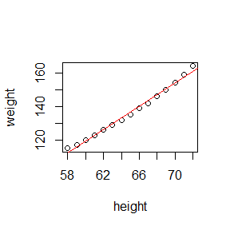

```r
plot(height,weight)
abline(lm_fit,col="red")
```

画出四副回归模型诊断图.

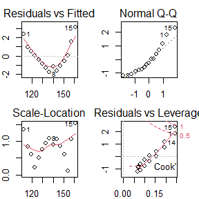

```r
par(mar = c(2,2,2,2))
par(mfrow=c(2,2))
plot(lm_fit)
```

tables:  
输出women数据集，回归拟合值及残差

```r
res<-data.frame(lm_fit$fitted.values,lm_fit$residuals)
knitr::kable(women)
```

| height | weight |
| --- | --- |
| 58 | 115 |
| 59 | 117 |
| 60 | 120 |
| 61 | 123 |
| 62 | 126 |
| 63 | 129 |
| 64 | 132 |
| 65 | 135 |
| 66 | 139 |
| 67 | 142 |
| 68 | 146 |
| 69 | 150 |
| 70 | 154 |
| 71 | 159 |
| 72 | 164 |

```r
knitr::kable(res)
```

| lm_fit.fitted.values | lm_fit.residuals |
| --- | --- |
| 112.5833 | 2.4166667 |
| 116.0333 | 0.9666667 |
| 119.4833 | 0.5166667 |
| 122.9333 | 0.0666667 |
| 126.3833 | -0.3833333 |
| 129.8333 | -0.8333333 |
| 133.2833 | -1.2833333 |
| 136.7333 | -1.7333333 |
| 140.1833 | -1.1833333 |
| 143.6333 | -1.6333333 |
| 147.0833 | -1.0833333 |
| 150.5333 | -0.5333333 |
| 153.9833 | 0.0166667 |
| 157.4333 | 1.5666667 |
| 160.8833 | 3.1166667 |

## A-21016-2021-09-23

## Question

Exercises 3.4, 3.11, and 3.20 (pages 94-96, Statistical Computating with R).

## Answer

3.4  
The Rayleigh density is$f(x)=\frac{x}{\sigma^2}e^{-\frac{x^2}{2\sigma^2}},x\geq0,\sigma>0$  
The CDF is $F(x)=\int_{0}^{x}f(x)dx=1-e^{-\frac{x^2}{2\sigma^2}}, x\geq0,\sigma>0$  
random samples from a Rayleigh(σ) distribution  
generate ramdom number$U\sim U(0,1)$  
Return$X=F^{-1}(U)=\sqrt{-2\sigma^2log\frac{1}{1-U}}$  
example1:

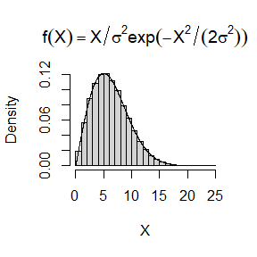

```r
n<-1e5
sigma<-5
lambda=sqrt(2)*sigma
U=runif(n)
X=sqrt(-2*sigma^2*log(U))

hist(X, prob = TRUE, main = expression(f(X)==X/sigma^2*exp(-X^2/(2*sigma^2))))
y <- seq(0, 20, .01)
lines(y, y/sigma^2*exp(-y^2/(2*sigma^2)))
```

example2:

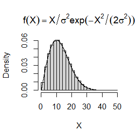

```r
n<-1e5
sigma<-10
lambda=sqrt(2)*sigma
U=runif(n)
X=sqrt(-2*sigma^2*log(U))
hist(X, prob = TRUE, main = expression(f(X)==X/sigma^2*exp(-X^2/(2*sigma^2))))
y <- seq(0, 40, .01)
lines(y, y/sigma^2*exp(-y^2/(2*sigma^2)))
```

example3:

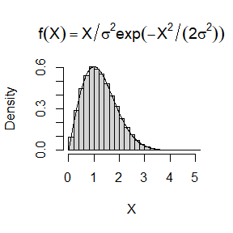

```r
n<-1e5
sigma<-1
lambda=sqrt(2)*sigma
U=runif(n)
X=sqrt(-2*sigma^2*log(U))
hist(X, prob = TRUE, main = expression(f(X)==X/sigma^2*exp(-X^2/(2*sigma^2))))
y <- seq(0, 40, .01)
lines(y, y/sigma^2*exp(-y^2/(2*sigma^2)))
```

3.11

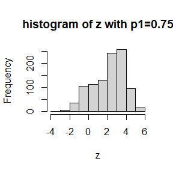

```r
n=1000
x1=rnorm(n,0,1)
x2=rnorm(n,3,1)
p1=0.75
p2=1-p1
r=sample(c(0,1),n,replace=T,prob=c(p1,p2))
z=r*x1+(1-r)*x2
hist(z,main="histogram of z with p1=0.75")
```

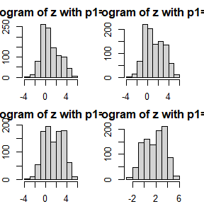

```r
#p1=0.3
r1=sample(c(0,1),n,replace=T,prob=c(0.3,0.7))
z1=r1*x1+(1-r1)*x2
#p1=0.4
r2=sample(c(0,1),n,replace=T,prob=c(0.4,0.6))
z2=r2*x1+(1-r2)*x2
#p1=0.5
r3=sample(c(0,1),n,replace=T,prob=c(0.5,0.5))
z3=r3*x1+(1-r3)*x2
#p1=0.6
r4=sample(c(0,1),n,replace=T,prob=c(0.6,0.4))
z4=r4*x1+(1-r4)*x2
par(mfrow=c(2,2))
par(mar = c(2,2,2,2))
hist(z1,main="histogram of z with p1=0.3")
hist(z2,main="histogram of z with p1=0.4")
hist(z3,main="histogram of z with p1=0.5")
hist(z4,main="histogram of z with p1=0.6")
```

Thus we can see that when p1=0.4,0.5 and 0.6, the histogram of z appears to be bimodal. so we make a conjecture that when p1 gets closer to 0.5,the bimodal mixture is more obvious.

3.20  
产生复合泊松-伽马过程随机数：

```r
rcompoundpois<-function(n,lambda,alpha,beta,t){
  X<-numeric(n)
  for(i in 1:n){
    N<-rpois(1,lambda*t)
    Y<-rgamma(N,alpha,beta)
    X[i]<-sum(Y)
  }
  return(X)
}
```

example:  
分别选取参数的值为$\lambda=1,3,3,5.\alpha=1,2,5,10.\beta=1,2,1,1$ 生成4种复合泊松-伽马过程随机数，得到其模拟均值和方差和理论期望方差的值为：

```r
n=1e5
t=10
lambda=c(1,3,3,5)
alpha=c(1,2,5,10)
beta=c(1,2,1,1)
X1=rcompoundpois(n,lambda[1],alpha[1],beta[1],t)
X2=rcompoundpois(n,lambda[2],alpha[2],beta[2],t)
X3=rcompoundpois(n,lambda[3],alpha[3],beta[3],t)
X4=rcompoundpois(n,lambda[4],alpha[4],beta[4],t)
mean=c(mean(X1),mean(X2),mean(X3),mean(X4))
sd2=c(sd(X1)^2,sd(X2)^2,sd(X3)^2,sd(X4)^2)
u=c(lambda*t*alpha/beta)
sigma2=lambda*t*alpha*(alpha+1)/(beta^2)
para=data.frame(mean,u,sigma2,sd2)
knitr::kable(para)
```

| mean | u | sigma2 | sd2 |
| --- | --- | --- | --- |
| 9.998641 | 10 | 20 | 19.92133 |
| 29.965019 | 30 | 45 | 45.00374 |
| 150.022034 | 150 | 900 | 894.86744 |
| 500.323783 | 500 | 5500 | 5517.14257 |

从表中可以看出，模拟的复合泊松-伽马过程随机数的均值与方差和理论结果十分相近。

## A-21016-2021-09-30

## Question

Exercises 5.4,5.9,5.13 and 5.14.

## 5.4

$\alpha=3,\beta=3$,the probability density function of beta(3,3) is
$$f(x)=\frac{\Gamma(6)}{\Gamma(3)^2}x^2(1-x)^2=30x^2(1-x)^2$$
the CDF is $F(x)=\int_{0}^{x}30x^2(1-x)^2dx, 0<x<1$
$g(X)=30X^3(1-X)^2,X\sim U(0,x)$
$F(x)=E(g(X))$

```r
beta.hat<-function(x){
  n<-1e4
  X<-runif(n,0,x)
  g<-30*X^2*(1-X)^2*x
  F<-mean(g)
  return(F)
}
F.hat=numeric(9)
x=c(0.1,0.2,0.3,0.4,0.5,0.6,0.7,0.8,0.9)
F=pbeta(x,3,3)
for(i in 1:9){
  F.hat[i]=beta.hat(x[i])
}
CDF<-data.frame(F,F.hat)
knitr::kable(CDF)
```

| F | F.hat |
| --- | --- |
| 0.00856 | 0.0083877 |
| 0.05792 | 0.0579751 |
| 0.16308 | 0.1614667 |
| 0.31744 | 0.3157134 |
| 0.50000 | 0.5046964 |
| 0.68256 | 0.6806838 |
| 0.83692 | 0.8386516 |
| 0.94208 | 0.9359443 |
| 0.99144 | 0.9923547 |

## 5.9

Choose inverse transformation method to generate random samples from a Rayleigh distribution with $\sigma=1$.  
The antithetic variables:  
$X=F^{-1}(U)=\sqrt{-2\sigma^2log(U)}$  
$X'=F^{-1}(1-U)=\sqrt{-2\sigma^2log(1-U)}$

```r
n=1e4
sigma=1

U_1=runif(n)
X=sqrt(-2*sigma^2*log(U_1))
Xx=sqrt(-2*sigma^2*log(1-U_1))
U_2=runif(n)
X_1=sqrt(-2*sigma^2*log(U_2))
U_3=runif(n)
X_2=sqrt(-2*sigma^2*log(U_3))

var1=sd((X+Xx)/2)^2
var2=sd((X_1+X_2)/2)^2
var<-data.frame(var1,var2)
knitr::kable(var)
```

| var1 | var2 |
| --- | --- |
| 0.010512 | 0.2145899 |

the variance of $\frac{X+X'}{2}$ is `var1`,the variance of $\frac{X_1+X_2}{2}$ is `var2`, the former is smaller.

## 5.13

$X_1\sim N(0,1)$
$$f_1(x)=\frac{1}{2\pi}e^{-\frac{x^2}{2}},-\infty<x<+\infty$$
$X_2\sim Rayleigh(\sigma=1)$
$$f_2(x)=xe^\frac{x^2}{2},x\ge0$$
$$\hat{\theta}=\int_{1}^{\infty}\frac{x^2}{\sqrt{2\pi}}e^{-\frac{x^2}{2}}dx=E[X_1^2I(X_1>1)]=E[\frac{X_2}{\sqrt{2\pi}}I(X_2>1)]$$

```r
n=1e4
X_1=rnorm(n)
X_1[X_1<1]=0
theta.hat1=mean(X_1^2)

U=runif(n)
X_2=sqrt(-2*log(U))
X_2[X_2<1]=0
theta.hat2=mean(X_2)/sqrt(2*pi)
var1<-sd(X_1^2)^2
var2<-sd(X_2/sqrt(2*pi))^2
f<-function(x){
x^2*exp(-x^2/2)/sqrt(2*pi)}
theta<-integrate(f,1,Inf)$value
f1<-c(theta.hat1,var1)
f2<-c(theta.hat2,var2)
theta.hat<-data.frame(f1=f1,f2=f2)
row.names(theta.hat)<-c("est","var")
knitr::kable(theta.hat)
```

|  | f1 | f2 |
| --- | --- | --- |
| est | 0.4051211 | 0.4071990 |
| var | 1.3001657 | 0.1289269 |

f2 can produce the smaller variance

## 5.14

According to the result of 5.13, we can choose the f2 importance function to estimate the integrate.

```r
n=1e4
U=runif(n)
X_2=sqrt(-2*log(U))
X_2[X_2<1]=0
theta.hat=mean(X_2)/sqrt(2*pi)

f<-function(x){
x^2*exp(-x^2/2)/sqrt(2*pi)}
theta<-integrate(f,1,Inf)$value

result<-data.frame(theta.hat=theta.hat,theta=theta)
knitr::kable(result)
```

| theta.hat | theta |
| --- | --- |
| 0.4007789 | 0.400626 |

## A-21016-2021-10-14

## Question

Exercises 6.5 and 6.A (page 180-181, Statistical Computating with R).  
6.5 Suppose a 95% symmetric t-interval is applied to estimate a mean, but the sample data are non-normal. Then the probability that the confidence interval covers the mean is not necessarily equal to 0.95. Use aMonte Carlo experiment to estimate the coverage probability of the t-interval for random samples of $χ2(2)$ data with sample size n = 20. Compare your t-interval results with the simulation results in Example 6.4. (The t-interval should be more robust to departures from normality than the interval for variance.)  
//

6.A Use Monte Carlo simulation to investigate whether the empirical Type I error rate of the t-test is approximately equal to the nominal significance level $\alpha$, when the sampled population is non-normal. The t-test is robust to mild departures from normality. Discuss the simulation results for the cases where the sampled population is (i) $χ2(1)$, (ii) Uniform(0,2), and (iii) Exponential( rate=1). In each case, test $H0 : μ = μ_0 vs H1 : μ \neq μ_0$, where μ0 is the mean of χ2(1), Uniform(0,2), and Exponential(1), respectively.

I If we obtain the powers for two methods under a particular simulation setting with 10,000 experiments: say, 0.651 for one method and 0.676 for another method. We want to know if the powers are different at 0.05 level. I What is the corresponding hypothesis test problem? I What test should we use? Z-test, two-sample t-test, paired-t test or McNemar test? Why? I Please provide the least necessary information for hypothesis testing.

## 6.5

```r
set.seed(5)
#norm mean=2,sd=3
n=20
m=1e4
alpha=0.05
U=V=y=numeric(m)
for(i in 1:m){
 X=rnorm(n,2,sd=3)
 U[i]<-mean(X)-qt(1-alpha/2,n-1)*sd(X)/sqrt(n)
 V[i]<-mean(X)+qt(1-alpha/2,n-1)*sd(X)/sqrt(n)
 if(U[i]<2&&V[i]>2) y[i]=1
 else y[i]=0
}
mean(y)
```

```
## [1] 0.953
```

```r
#chisq
set.seed(5)
n=20
m=1e4
alpha=0.05
U=V=y=numeric(m)
for(i in 1:m){
 X=rchisq(n,2)
 U[i]<-mean(X)-qt(1-alpha/2,n-1)*sd(X)/sqrt(n)
 V[i]<-mean(X)+qt(1-alpha/2,n-1)*sd(X)/sqrt(n)
 if(U[i]<2&&V[i]>2) y[i]=1
 else y[i]=0
}
mean(y)
```

```
## [1] 0.9164
```

```r
#normal
n <- 20
alpha <- .05
UCL <- replicate(1000, expr = {
x <- rnorm(n, mean = 0, sd = 2)
(n-1) * var(x) / qchisq(alpha, df = n-1)
} )
mean(UCL > 4)
```

```
## [1] 0.938
```

```r
#chisq
n <- 20
alpha <- .05
UCL <- replicate(1000, expr = {
x <- rchisq(n,2)
(n-1) * var(x) / qchisq(alpha, df = n-1)
} )
mean(UCL > 4)
```

```
## [1] 0.78
```

we can see the t-interval should be more robust to departures from normality than the interval for variance.

## 6.A

case 1 chisquare(1)

```r
#n=20
n=20
m=1e4
alpha=0.05
U=V=y=p=numeric(m)
for(i in 1:m){
 X=rchisq(n,1)
 T[i]=abs((mean(X)-1)*sqrt(n)/sd(X))
 p[i]=2*pt(T[i],n-1,lower.tail = F)
 if(p[i]<alpha) y[i]=1
 else y[i]=0
}
#the result is mean(y)
mean(y)
```

```
## [1] 0.1072
```

```r
#n=200
n=200
m=1e4
alpha=0.05
U=V=y=p=numeric(m)
for(i in 1:m){
 X=rchisq(n,1)
 T[i]=abs((mean(X)-1)*sqrt(n)/sd(X))
 p[i]=2*pt(T[i],n-1,lower.tail = F)
 if(p[i]<alpha) y[i]=1
 else y[i]=0
}
mean(y)
```

```
## [1] 0.0534
```

case2 Uniform(0,2)

```r
#n=20
n=20
m=1e4
alpha=0.05
U=V=y=p=numeric(m)
for(i in 1:m){
 X=runif(n,0,2)
 T[i]=abs((mean(X)-1)*sqrt(n)/sd(X))
 p[i]=2*pt(T[i],n-1,lower.tail = F)
 if(p[i]<alpha) y[i]=1
 else y[i]=0
}
mean(y)
```

```
## [1] 0.0508
```

```r
#n=200
n=200
m=1e4
alpha=0.05
U=V=y=p=numeric(m)
for(i in 1:m){
 X=runif(n,0,2)
 T[i]=abs((mean(X)-1)*sqrt(n)/sd(X))
 p[i]=2*pt(T[i],n-1,lower.tail = F)
 if(p[i]<alpha) y[i]=1
 else y[i]=0
}
mean(y)
```

```
## [1] 0.0515
```

case3 Exponential(rate=1)

```r
#n=20
n=20
m=1e4
alpha=0.05
U=V=y=p=numeric(m)
for(i in 1:m){
 X=rexp(n,1)
 T[i]=abs((mean(X)-1)*sqrt(n)/sd(X))
 p[i]=2*pt(T[i],n-1,lower.tail = F)
 if(p[i]<alpha) y[i]=1
 else y[i]=0
}
mean(y)
```

```
## [1] 0.0783
```

```r
#n=200
n=200
m=1e4
alpha=0.05
U=V=y=p=numeric(m)
for(i in 1:m){
 X=rexp(n,1)
 T[i]=abs((mean(X)-1)*sqrt(n)/sd(X))
 p[i]=2*pt(T[i],n-1,lower.tail = F)
 if(p[i]<alpha) y[i]=1
 else y[i]=0
}
mean(y)
```

```
## [1] 0.0558
```

## 3

(1)
$$H_0:\overline{power}_1=\overline{power}_2 \ vs\ H_1:\overline{power}_1\neq \overline{power}_2$$
其中 $\overline{power}_1=\frac{1}{n}\sum_{i=1}^npower_1[i]$
$\overline{power}_2=\frac{1}{n}\sum_{i=1}^npower_2[i]$
(2)使用配对t检验(paired t-test).令$d[i]=power_1[i]-power_2[i]$,则$H_0: \bar{d}=0,\ H_1:\bar{d}\neq 0$. $d[i]$相互独立同分布，且存在期望和方差。假设d服从正态分布，$H_0$为真时，$\frac{\sqrt{n}\bar{d}}{sd(d)}\sim t_{n-1}$，因此当|$\frac{\sqrt{n}\bar{d}}{sd(d)}|>t_{\alpha/2}$时，拒绝$H_0$,，接受$H_1$, 当|$\frac{\sqrt{n}\bar{d}}{sd(d)}|\leq t_{\alpha/2}$时，拒绝$H_1$,，接受$H_0$.
(3)需要假设d服从正态分布，得到$power_1,power_2$的每个具体数据，样本量n和$\alpha$.

## A-21016-2021-10-21

## Question

Exercises 6.C (pages 182, Statistical Computating with R). Repeat Examples 6.8 and 6.10 for Mardia’s multivariate skewness test.

## Answer

Example6.8
Assume $X\sim N(\mathbf{\mu},\Sigma)$, where
$$\begin{aligned}
\mu=\left(
\begin{array}
0
0 \\
0\\
0
\end{array}
\right)
\end{aligned}
\quad
\Sigma=\left(
\begin{array}
{ccc}
1\ \ 0\ \ 0\\
0\ \ 1\ \ 0 \\
0\ \ 0\ \ 1 \\
\end{array}
\right)$$

```r
library(MASS)

sk <- function(x) {
  #computes the sample skewness coeff.
  xbar <- colMeans(x)
  xbarm<-matrix(rep(xbar,nrow(x)),nrow(x),ncol(x),byrow = T)
  sigmabar<-t(x-xbarm)%*%(x-xbarm)/nrow(x)
  a <- (x-xbarm)%*%solve(sigmabar)%*%t(x-xbarm)
  b<-sum(colSums(a^3))/(nrow(x)^2)
  return( b )
}

alpha=0.05
n <- c(10, 20, 30, 50, 100, 500);m <- 10000
cv <- qchisq(0.95,10)
mu=c(0,0,0)
sigma=matrix(c(1,0,0,0,1,0,0,0,1),3,3)
p.reject <- numeric(length(n)) #to store sim. results

for(i in 1:length(n)){

  sktests <- numeric(m)

  for (j in 1:m) {
    x<-mvrnorm(n[i],mu,sigma)
    b=sk(x)
    sktests[j] <- as.integer(n[i]*b/6 >= cv )
  }
  p.reject[i] <- mean(sktests)
}
p.reject
```

```
## [1] 0.0006 0.0197 0.0355 0.0422 0.0503 0.0493
```

The result p.reject shows that when n>50, the t1e is close to 0.05.
Example 6.10
Assume $X\sim (1-\epsilon)N(\mathbf{\mu},\Sigma_1)+\epsilon N(\mu,\Sigma_2),0\leq \epsilon \leq 1$, where
$$\begin{aligned}
\mu=\left(
\begin{array}
0
0 \\
0\\
0
\end{array}
\right)
\end{aligned}
\quad
\Sigma_1=\left(
\begin{array}
{ccc}
1\ \ 0\ \ 0\\
0\ \ 1\ \ 0 \\
0\ \ 0\ \ 1 \\
\end{array}
\right)
\quad
\Sigma_2=\left(
\begin{array}
{ccc}
100\ \ 0\ \ 0\\
0\ \ 100\ \ 0 \\
0\ \ 0\ \ 100 \\
\end{array}
\right)$$

From the result of 6.8, we choose n=50.

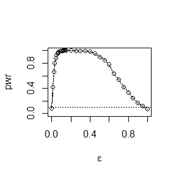

```r
library(MASS)

sk <- function(x) {
  #computes the sample skewness coeff.
  xbar <- colMeans(x)
  xbarm<-matrix(rep(xbar,nrow(x)),nrow(x),ncol(x),byrow = T)
  sigmabar<-t(x-xbarm)%*%(x-xbarm)/nrow(x)
  a <- (x-xbarm)%*%solve(sigmabar)%*%t(x-xbarm)
  b<-sum(colSums(a^3))/(nrow(x)^2)
  return( b )
}
alpha <- .1
n <- 50
m <- 2500
epsilon <- c(seq(0, .15, .01), seq(.15, 1, .05))
N <- length(epsilon)
pwr <- numeric(N)
mu=c(0,0,0)
sigma1=matrix(c(1,0,0,0,1,0,0,0,1),3,3)
sigma2=matrix(c(100,0,0,0,100,0,0,0,100),3,3)
#critical value for the skewness test
cv <- qchisq(1-alpha,10)

for (j in 1:N) { #for each epsilon
  e <- epsilon[j]
  sktests <- numeric(m)

  for (i in 1:m) { #for each replicate
    index <- sample(c(0, 1), replace = TRUE,size = n, prob = c(1-e, e))
    x1 <- mvrnorm(n, mu, sigma1)
    x2 <- mvrnorm(n, mu, sigma2)
    x<-(1-index)*x1+index*x2
    sktests[i] <- as.integer(n*sk(x)/6 >= cv)
  }
  pwr[j] <- mean(sktests)
}
plot(epsilon, pwr, type = "b",
     xlab = bquote(epsilon), ylim = c(0,1))
abline(h = .1, lty = 3)
se <- sqrt(pwr * (1-pwr) / m) #add standard errors
lines(epsilon, pwr+se, lty = 3)
lines(epsilon, pwr-se, lty = 3)
```

the result shows that the power curve crosses the horizontal line corresponding to $\alpha=0.1$ at both endpoints, $\epsilon=0$ and $\epsilon=1$ where the alternative is normally distributed. For $0 < \epsilon < 1$ the empirical power of the test is greater than 0.10 and highest when $\epsilon$ is about 0.15.

## A-21016-2021-10-28

## Question

Exercises 7.7, 7.8, 7.9, and 7.B (pages 213, Statistical Computating with R).

## Answer

7.7

```r
library(boot)
library(bootstrap)
data=scor
B=2000
n=nrow(data)
covhat=cov(data)
eigenhat=eigen(covhat)
thetahat=eigenhat$values[1]/sum(eigenhat$values)
thetastar=numeric(B)
for(i in 1:B)
{
  index=sample(c(1:n),n,replace = TRUE)
  xstar=data[index,]
  cov=cov(xstar)
  eigen=eigen(cov)
  thetastar[i]=eigen$values[1]/sum(eigen$values)
}
bias=mean(thetastar)-thetahat
sd=sd(thetastar)
c(bias.boot=bias,sd.boot=sd)
```

```
##   bias.boot     sd.boot
## 0.001492416 0.047993067
```

7.8

```r
library(bootstrap)
stat<-function(x,i){
  cov=cov(x[i,])
  eigen=eigen(cov)
  theta=eigen$values[1]/sum(eigen$values)
  return(theta)
}

data=scor
n=nrow(data)
thetahat=stat(data,(1:n))

theta.jack=numeric(n)
for(i in 1:n){
  theta.jack[i]=stat(data,(1:n)[-i])
}
bias.jack <- (n-1)*(mean(theta.jack)-thetahat)
se.jack <- sqrt((n-1)*mean((theta.jack-mean(theta.jack))^2))
round(c(thetahat=thetahat,bias.jack=bias.jack,
se.jack=se.jack),4)
```

```
##  thetahat bias.jack   se.jack
##    0.6191    0.0011    0.0496
```

7.9

```r
library(boot)
library(bootstrap)
stat<-function(x,i){
  cov=cov(x[i,])
  eigen=eigen(cov)
  theta=eigen$values[1]/sum(eigen$values)
  return(theta)
}
data=scor
obj=boot(data,stat,R=2000)
ci <- boot.ci(obj,type=c("perc","bca"))
ci.perc<-ci$percent[4:5]
ci.bca<-ci$bca[4:5]
c(ci.perc=ci.perc,ci.bca=ci.bca)
```

```
##  ci.perc1  ci.perc2   ci.bca1   ci.bca2
## 0.5221113 0.7088348 0.5220812 0.7086439
```

7.B

```r
library(boot)
stat<-function(x,i){
  xbar=mean(x[i])
  m2=mean((x[i]-xbar)^3)
  m3=mean((x[i]-xbar)^2)
  return(m2/m3^1.5)
}
#normal populations (skewness 0)
m=1e3
n=20
u=1;sd=1
ci.basic<-matrix(NA,m,2)
ci.perc<-matrix(NA,m,2)
ci.norm<-matrix(NA,m,2)
for(i in 1:m){
data=rnorm(n,u,sd)
obj=boot(data,stat,R=999)
ci=boot.ci(obj,type=c("norm","basic","perc"))
ci.norm[i,]=ci$norm[2:3]
ci.basic[i,]=ci$basic[4:5]
ci.perc[i,]=ci$percent[4:5]
}
#正态分布N(1,1)的norm,basic,percent置信区间覆盖率
cat('normalnorm =',mean(ci.norm[,1]<= 0 & ci.norm[,2]>=0),
    'normalbasic =',mean(ci.basic[,1]<= 0 & ci.basic[,2]>=0),
'normalperc =',mean(ci.perc[,1]<=0 & ci.perc[,2]>=0))
```

```
## normalnorm = 0.882 normalbasic = 0.882 normalperc = 0.97
```

```r
#正态分布N(1,1)的norm,basic,percent置信区间左侧和右侧覆盖率
cat('normalnormleft =',mean(ci.norm[,1]<=0),
    'normalnormright =',mean(ci.norm[,2]>=0),
    'normalbasicleft =',mean(ci.basic[,1]<= 0),
    'normalbasicright =',mean(ci.basic[,2]>=0),
'normalpercleft =',mean(ci.perc[,1]<=0),
'normalpercright =',mean(ci.perc[,2]>=0))
```

```
## normalnormleft = 0.94 normalnormright = 0.942 normalbasicleft = 0.943 normalbasicright = 0.939 normalpercleft = 0.987 normalpercright = 0.983
```

```r
#χ2(5) distributions
df=5
skewness=sqrt(8/df)
ci.basic<-matrix(NA,m,2)
ci.perc<-matrix(NA,m,2)
ci.norm<-matrix(NA,m,2)
for(i in 1:m){
data=rchisq(n,df)
obj=boot(data,stat,R=999)
ci=boot.ci(obj,type=c("norm","basic","perc"))
ci.norm[i,]=ci$norm[2:3]
ci.basic[i,]=ci$basic[4:5]
ci.perc[i,]=ci$percent[4:5]
}
#卡方分布norm,basic,percent置信区间覆盖率
cat('chisqnorm =',mean(ci.norm[,1]<= skewness & ci.norm[,2]>=skewness),
    'chisqbasic =',mean(ci.basic[,1]<= skewness & ci.basic[,2]>=skewness),
'chisqperc =',mean(ci.perc[,1]<=skewness & ci.perc[,2]>=skewness))
```

```
## chisqnorm = 0.746 chisqbasic = 0.719 chisqperc = 0.729
```

```r
#卡方分布norm,basic,percent置信区间的左侧和右侧的覆盖率
cat('chisqnormleft =',mean(ci.norm[,1]<= skewness),
    'chisqnormright =',mean(ci.norm[,2]>=skewness),
    'chisqbasicleft =',mean(ci.basic[,1]<= skewness),
    'chisqbasicright =',mean(ci.basic[,2]>=skewness),
'chisqpercleft =',mean(ci.perc[,1]<=skewness),
'chisqpercright =',mean(ci.perc[,2]>=skewness))
```

```
## chisqnormleft = 0.979 chisqnormright = 0.767 chisqbasicleft = 0.961 chisqbasicright = 0.758 chisqpercleft = 1 chisqpercright = 0.729
```

## A-21016-2021-11-04

## Question

1.Exercise 8.2 (page 242, Statistical Computating with R).  
2.Design experiments for evaluating the performance of the NN,energy, and ball methods in various situations.  
Unequal variances and equal expectations  
Unequal variances and unequal expectations  
Non-normal distributions: t distribution with 1 df (heavy-tailed distribution), bimodel distribution (mixture of two normal distributions)  
Unbalanced samples (say, 1 case versus 10 controls)  
Note: The parameters should be chosen such that the powers are distinguishable (say, range from 0.3 to 0.8).

## Answer

8.2  
Use the samples from normal distribution, $x \sim N(0,1)$ and $y \sim N(100,1)$, n=30.

```r
set.seed(345)
R=999
K=1:60
n<-30
x<-rnorm(n,0,1)
y<-rnorm(n,100,1)
z<-c(x,y)
t0_cortest<-cor.test(x,y)$statistic
p0_cortest<-cor.test(x,y)$p.value
t0_spearman<-cor(x,y,method = "spearman")
rep1=numeric(R)
rep2=numeric(R)
for(i in 1:R){
  k <- sample(K, size = n, replace = FALSE)
  x1 <- z[k]; y1 <- z[-k]
  rep1[i] <- cor.test(x1, y1)$statistic
  rep2[i]<-cor(x1,y1,method = "spearman")
}
p_cortest <- mean(abs(c(t0_cortest, rep1)) >= abs(t0_cortest))
p_spearman <- mean(abs(c(t0_spearman, rep2)) >= abs(t0_spearman))
round(c(p0_cortest=p0_cortest,p_cortest=p_cortest,p_spearman=p_spearman),3)
```

```
## p0_cortest  p_cortest p_spearman
##      0.002      0.006      0.002
```

we set $\alpha=0.05$ and both the bivariate Spearman rank correlation test and cor test can reject the null hypothesis. From the result the pvalue of spearman is smaller than pvalue of cortest.

2

```r
library(RANN)
library(boot)
library(energy)
library(Ball)

#NN
set.seed(12345)
Tn <- function(z, ix, sizes,k) {
n1 <- sizes[1]; n2 <- sizes[2]; n <- n1 + n2
if(is.vector(z)) z <- data.frame(z);
z <- z[ix, ];
NN <- nn2(data=z, k=k+1) # What is the first column?
block1 <- NN$nn.idx[1:n1,-1]
block2 <- NN$nn.idx[(n1+1):n,-1]
i1 <- sum(block1 <= n1); i2 <- sum(block2 > n1)
(i1 + i2) / (k * n)
}
#Unequal variances and equal expectations
n=30
x<-rnorm(n,0,1)
y<-rnorm(n,0,5)
z <- c(x, y)
N=c(length(x),length(y))
boot.obj <- boot(data = z, statistic = Tn, R = 999,
sim = "permutation", sizes = N, k=3)
ts <- c(boot.obj$t0,boot.obj$t)
NN_p.value <- mean(ts>=ts[1])

boot.obs <- eqdist.etest(z, sizes=N, R=999)
energy_p.value <- boot.obs$p.value
ball_p.value = bd.test(x = x, y = y, num.permutations=9999)$p.value

round(c(NN_p.value=NN_p.value,energy_p.value=energy_p.value,ball_p.value),4)
```

```
##         NN_p.value     energy_p.value bd.constant.pvalue
##              1e-03              1e-03              1e-04
```

```r
#Unequal variances and unequal expectations
set.seed(12345)
n=30
x<-rnorm(n,0,1)
y<-rnorm(n,2,5)
z <- c(x, y)
N=c(length(x),length(y))
boot.obj <- boot(data = z, statistic = Tn, R = 999,
sim = "permutation", sizes = N, k=3)
ts <- c(boot.obj$t0,boot.obj$t)
NN_p.value <- mean(ts>=ts[1])

boot.obs <- eqdist.etest(z, sizes=N, R=999)
energy_p.value <- boot.obs$p.value
ball_p.value = bd.test(x = x, y = y, num.permutations=9999)$p.value

round(c(NN_p.value=NN_p.value,energy_p.value=energy_p.value,ball_p.value),4)
```

```
##         NN_p.value     energy_p.value bd.constant.pvalue
##              1e-03              1e-03              1e-04
```

```r
#t distribution with 1 df (heavy-tailed
#distribution), bimodel distribution (mixture of two normal
#distributions)
set.seed(345)
n=30
x<-rt(n,1)
y1<-rnorm(n,0,1)
y2<-rnorm(n,3,1)
k<-sample(c(0,1),n,replace = TRUE)
y<-k*y1+(1-k)*y2
z <- c(x, y)
N=c(length(x),length(y))
boot.obj <- boot(data = z, statistic = Tn, R = 999,
sim = "permutation", sizes = N, k=3)
ts <- c(boot.obj$t0,boot.obj$t)
NN_p.value <- mean(ts>=ts[1])

boot.obs <- eqdist.etest(z, sizes=N, R=999)
energy_p.value <- boot.obs$p.value
ball_p.value = bd.test(x = x, y = y, num.permutations=9999)$p.value

round(c(NN_p.value=NN_p.value,energy_p.value=energy_p.value,ball_p.value),4)
```

```
##         NN_p.value     energy_p.value bd.constant.pvalue
##             0.0800             0.0070             0.0029
```

```r
#Unbalanced samples (say, 1 case versus 10 controls)
set.seed(234)
n1=10;n2=100
x<-rnorm(n1,0,1)
y<-rnorm(n2,2,1)

z <- c(x, y)
N=c(length(x),length(y))
boot.obj <- boot(data = z, statistic = Tn, R = 999,
sim = "permutation", sizes = N, k=3)
ts <- c(boot.obj$t0,boot.obj$t)
NN_p.value <- mean(ts>=ts[1])

boot.obs <- eqdist.etest(z, sizes=N, R=999)
energy_p.value <- boot.obs$p.value
ball_p.value = bd.test(x = x, y = y, num.permutations=9999)$p.value

round(c(NN_p.value=NN_p.value,energy_p.value=energy_p.value,ball_p.value),4)
```

```
##         NN_p.value     energy_p.value bd.constant.pvalue
##              1e-03              1e-03              1e-04
```

From the result, we can conclude that the Pvalue of NN method is the largest in various situations, and the Pvalue of ball method is the smallest.  
In various situations, the energy and ball method can distinguish the sample well($\alpha=0.05$ and $p<\alpha$). However, in the Non-normal distributions samples, the NN method cannot reject the null hypothesis when $\alpha=0.05$, it seem that the energy and ball method is better than NN when the sample from Non-normal distributions.

## A-21016-2021-11-11

## Qusetion

Exercies 9.3 and 9.8 (pages 277-278, Statistical Computating with R). For each of the above exercise, use the Gelman-Rubin method to monitor convergence of the chain, and run the chain until it converges approximately to the target distribution according to R < 1.2.

## 9.3

For the standard Cauchy distribution, choose normal distribution $Y|X_t \sim N(X_t,\sigma^2)$.

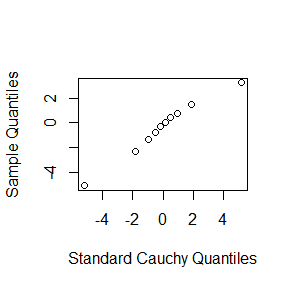

```r
set.seed(12345)
m<-5000
sigma=0.5
x<-numeric(m)
x[1]<-rnorm(1,0,sigma)
k=0
u <- runif(m)


for(i in 2:m){
  y<- rnorm(1, x[i-1], sigma)
  if(u[i]<= (dt(y, 1) / dt(x[i-1], 1)) ) x[i]=y
  else {x[i]=x[i-1]
  k=k+1}
}

b<-1001
y1<-x[b:m]
a<-ppoints(10)
Qsample <- quantile(y1, a)
QR<-qt(a,1)
qqplot(QR, Qsample, main="",
xlab="Standard Cauchy Quantiles", ylab="Sample Quantiles")
```

```r
res<-data.frame(QR,Qsample)
knitr::kable(res)
```

|  | QR | Qsample |
| --- | --- | --- |
| 6.097561% | -5.1562719 | -5.0727732 |
| 15.85366% | -1.8389697 | -2.2942948 |
| 25.60976% | -0.9624035 | -1.3283044 |
| 35.36585% | -0.4951315 | -0.7415115 |
| 45.12195% | -0.1544595 | -0.3264677 |
| 54.87805% | 0.1544595 | 0.0488675 |
| 64.63415% | 0.4951315 | 0.4040446 |
| 74.39024% | 0.9624035 | 0.7845436 |
| 84.14634% | 1.8389697 | 1.4893191 |
| 93.90244% | 5.1562719 | 3.2214994 |

## 9.8

set a=2,b=1,n=10

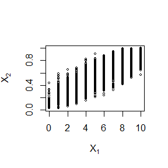

```r
N=5000
burn=1000
X <- matrix(0, N, 2)
a=2
b=1
n=10
X[1,]=c(5,0.5)

for (i in 2:N) {
x2 <- X[i-1, 2]
X[i, 1] <- rbinom(1, n, x2)
x1 <- X[i, 1]
X[i, 2] <- rbeta(1,x1+a,n-x1+b)
}
b <- burn + 1
x <- X[b:N, ]
plot(x, main="", cex=.5, xlab=bquote(X[1]),
     ylab=bquote(X[2]), ylim=range(x[,2]))
```

## convergence of the chain

9.3

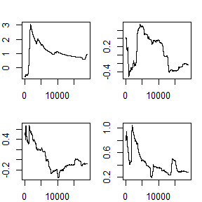

```r
#monitor convergence of the chain
Gelman.Rubin <- function(psi) {
  psi<-as.matrix(psi)
  m<-ncol(psi)
  n<-nrow(psi)
  psi.means<-rowMeans(psi)
  B<-n*var(psi.means)
  psi.w<-apply(psi,1,"var")
  W<-mean(psi.w)
  v.hat<-W*(n-1)/n+B/n
  r.hat<-v.hat/W
  return(r.hat)
}

cauchy.chain<-function(sigma,N,X1){
  x<-rep(0,N)
  x[1]<-X1
  u<-runif(N)

  for(i in 2:N){
    y<-rnorm(1,x[i-1],sigma)
    r=dt(y,1)/dt(x[i-1],1)
    if(u[i]<=r) x[i]=y
    else x[i]=x[i-1]
  }
  return(x)
}

set.seed(12345)
sigma=0.5
n<-20000
b<-1000
x0<-c(-10,-5,5,10)
X<-matrix(0,4,n)
for(i in 1:4)
  X[i,]=cauchy.chain(sigma,n,x0[i])

psi<-t(apply(X,1,cumsum))
for(i in 1:nrow(psi))
psi[i,] <- psi[i,] / (1:ncol(psi))


par(mfrow=c(2,2))
par(mar=c(2,2,2,1))
for (i in 1:4)
plot(psi[i, (b+1):n], type="l",
xlab=i, ylab=bquote(psi))
```

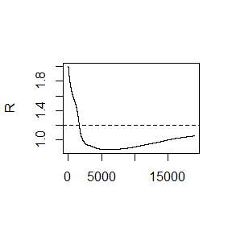

```r
par(mfrow=c(1,1))
par(mar=c(5.1,4.1,4.1,2.1))

rhat <- rep(0, n)
for (j in (b+1):n)
rhat[j] <- Gelman.Rubin(psi[,1:j])
plot(rhat[(b+1):n], type="l", xlab="", ylab="R")
abline(h=1.2, lty=2)
```

9.8

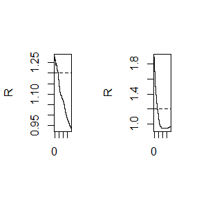

```r
Gelman.Rubin <- function(psi) {
  psi<-as.matrix(psi)
  m<-ncol(psi)
  n<-nrow(psi)
  psi.means<-rowMeans(psi)
  B<-n*var(psi.means)
  psi.w<-apply(psi,1,"var")
  W<-mean(psi.w)
  v.hat<-W*(n-1)/n+B/n
  r.hat<-v.hat/W
  return(r.hat)
}

gibbs.chain<-function(N,x0){
  X <- matrix(0, N, 2)
  a=2
  b=1
  n=10
  X[1,]=x0
  for (i in 2:N) {
x2 <- X[i-1, 2]
X[i, 1] <- rbinom(1, n, x2)
x1 <- X[i, 1]
X[i, 2] <- rbeta(1,x1+a,n-x1+b)
}
  return(X)
}

set.seed(8)
n<-20000
b<-1000
x0<-matrix(data=c(1,3,5,9,0.7,0.5,0.3,0.1),nrow = 4,ncol=2)
X1<-matrix(0,4,n)
X2<-matrix(0,4,n)
for(i in 1:4) {
  X1[i,]=gibbs.chain(n,x0[i,])[,1]
  X2[i,]=gibbs.chain(n,x0[i,])[,2]
}

psi1<-t(apply(X1,1,cumsum))
psi2<-t(apply(X2,1,cumsum))
for(i in 1:nrow(psi1)){
psi1[i,] <- psi1[i,] / (1:ncol(psi1))
psi2[i,] <- psi2[i,] / (1:ncol(psi2))
}

rhat1 <- rep(0, n)
rhat2 <- rep(0, n)
for (j in (b+1):n){
rhat1[j] <- Gelman.Rubin(psi1[,1:j])
rhat2[j] <- Gelman.Rubin(psi2[,1:j])
}
par(mfrow=c(1,2))
plot(rhat1[(b+1):n], type="l", xlab="", ylab="R")
abline(h=1.2, lty=2)
plot(rhat2[(b+1):n], type="l", xlab="", ylab="R")
abline(h=1.2, lty=2)
```

## A-21016-2021-11-18

## Qusetion

Exercises 11.3 and 11.5 (pages 353-354, Statistical Computing with R)  
Suppose $T_1, . . . ,T_n$ are i.i.d. samples drawn from the exponential distribution with expectation. Those values greater than are not observed due to right censorship, so that the observed values are $Y_i = T_iI(Ti<\tau)+\tau I(Ti>\tau), i= 1, . . . , n.$Suppose$\tau = 1$ and the observed $Y_i$ values are as follows: 0.54, 0.48, 0.33, 0.43, 1.00, 1.00, 0.91, 1.00, 0.21, 0.85  
Use the E-M algorithm to estimate, compare your result with the observed data MLE (note: $Y_i$ follows a mixture distribution).

## Answer

11.3  
(1)

```r
g<-function(k,d){
  return(
    exp(lgamma(k+3/2)+lgamma((d+1)/2)-lgamma(k+d/2+1))
    )
}


kth<-function(a,k){
  d<-length(a)
  anorm<-0
for(i in 1:d){
    anorm<-a[i]^2+anorm
}
  b=anorm^(k+1)/((2*k+1)*(2*k+2))
return((-1)^k*b*g(k,d)/(factorial(k)*2^k))
}
```

```r
sumfun<-function(a,k){
  res<-0
  for(i in 1:(k+1)){
    res<-res+kth(a,i-1)
  }
  return(res)
}
```

(3)取$a=(1,2)^T,k=10,100,100,d=2$

```r
a<-c(1,2)
k=c(10,100,100)
funsum<-numeric(3)
for(i in 1:3){
  funsum[i]=sumfun(a,k[i])
}
res<-data.frame(k,funsum)
knitr::kable(res)
```

| k | funsum |
| --- | --- |
| 10 | 1.532165 |
| 100 | 1.532164 |
| 100 | 1.532164 |

11.5  
根据题意方程两侧分别为$P(0<t(k-1)<c_{k-1})$和$P(0<t(k)<c_k)$

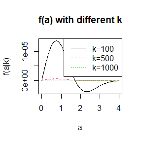

```r
sa<-function(a,k){
  ck=sqrt(a^2*k/(k+1-a^2))
  res=1/2-pt(ck,k,lower.tail = F)
  return(res)
}
f<-function(a,k){
  return(sa(a,k)-sa(a,k-1))
}

k<-c(4:25,100,500,1000)
a <- seq(0, 4, by=0.01)
plot(a, f(a, k[23]), lty=1, col=1, type="l", xlim=c(0, 4), xlab="a", ylab="f(a|k)", main="f(a) with different k")
lines(a, f(a, k[24]), xlim = c(0, 4), lty=2, col=2)
lines(a, f(a, k[25]), xlim = c(0, 4), lty=3, col=3)
legend("topright", legend=c("k=100", "k=500", "k=1000"), col=1:3,lty=1:3)
```

```r
solve <- function(k){
  output = uniroot(function(a){sa(a,k)-sa(a,k-1)},lower=1,upper=2)
  output$root
}

root<-matrix(0,2,length(k))
root[1,]=k
for(i in 1:length(k)){
  root[2,i]<-solve(k[i])
}

rownames(root) = c('k','A(k)')
print(root)
```

```
##          [,1]     [,2]     [,3]    [,4]     [,5]     [,6]     [,7]      [,8]
## k    4.000000 5.000000 6.000000 7.00000 8.000000 9.000000 10.00000 11.000000
## A(k) 1.492103 1.533556 1.562744 1.58443 1.601185 1.614521  1.62539  1.634419
##           [,9]     [,10]    [,11]     [,12]     [,13]     [,14]     [,15]
## k    12.000000 13.000000 14.00000 15.000000 16.000000 17.000000 18.000000
## A(k)  1.642038  1.648554  1.65419  1.659114  1.663452  1.667303  1.670745
##         [,16]     [,17]     [,18]     [,19]    [,20]     [,21]     [,22]
## k    19.00000 20.000000 21.000000 22.000000 23.00000 24.000000 25.000000
## A(k)  1.67384  1.676637  1.679178  1.681496  1.68362  1.685572  1.687373
##           [,23]      [,24]       [,25]
## k    100.000000 500.000000 1000.000000
## A(k)   1.720608   1.729755    1.730907
```

所得结果与11.4结果相同。

E-M algorithm

假设大于$\tau$的观测数据为$X=x_1,x_2,...,x_m$，$Y=y_1,...,y_n$为小于和等于$\tau$的观测数据。
似然函数为
$$(\frac{1}{\lambda})^ne^{-\frac{1}{\lambda}(\sum_{i=1}^mx_i+\sum_{j=1}^{n-m}y_j)},\lambda>0,x_i,y_j>0,i=1,..,m,j=1,...,n-m$$
取对数得到
$$l(\lambda|X,Y)=log((\frac{1}{\lambda})^ne^{-\frac{1}{\lambda}(\sum_{i=1}^mx_i+\sum_{j=1}^{n-m}y_j)})=-nlog\lambda-\frac{1}{\lambda}(\sum_{i=1}^mx_i+\sum_{j=1}^{n-m}y_j)$$
对第(j-1)次迭代得到的$\lambda^{j-1}$ E步期望为：
$$\begin{aligned}
Q(\lambda,\lambda^{(j-1)})&=E_{X|\lambda^{(j-1)},Y}[l(\lambda|X,Y)]\\
&=-nlog\lambda-\frac{1}{\lambda}(\sum_{i=1}^mE(X_i|\lambda^{(j-1)},Y)+\sum_{j=1}^{n-m}y_j)
\end{aligned}$$
其中
$$E(X_i|\lambda^{(j-1)},Y)=\int_{\tau}^\infty x\frac{1}{\lambda^{(j-1)}}e^{-\frac{1}{\lambda^{(j-1)}}(x-\tau)}dx=(\tau+\lambda^{(j-1)})$$
根据题意,$n=10,m=3,\tau=1,\sum_{j=1}^{n-m}y_j=3.75$
$$Q(\lambda,\lambda^{(j-1)})=-10log\lambda-\frac{1}{\lambda}(3(1+\lambda^{(j-1)})+3.75)$$
M步求最大值：
$$\lambda^{(j)}=argmaxQ(\lambda,\lambda^{(j-1)})=\frac{3(1+\lambda^{(j-1)})+3.75)}{10}$$
对上述两步循环迭代直至收敛。

MLE估计：
$$\hat{\lambda}=\frac{\sum_{i=1}^mx_i+\sum_{j=1}^{n-m}y_j}{r}=\frac{3+3.75}{7}\approx0.9643$$

```r
em<-function(lambda0){
  e<-0.0001
  n=10000
for(i in 1:n){
  lambda=(3*(1+lambda0)+3.75)/10
  if(lambda-lambda0>e)
    lambda0=lambda
  else
    break
 }
return(lambda)
}
res<-matrix(0,2,4)
  lambda0=c(0.2,0.5,1,2)
  res[1,]=lambda0
for(i in 1:4){
res[2,i]=em(lambda0[i])
}
  rownames(res)=c('lambda0','lambdahat')
  print(res)
```

```
##                [,1]      [,2]  [,3]  [,4]
## lambda0   0.2000000 0.5000000 1.000 2.000
## lambdahat 0.9642707 0.9642553 0.975 1.275
```

根据结果可得，当初值选择小于等于1时，EM算法所得到的结果与MLE估计结果相似。